# Genetic identification

Andrie de Vries

15 March 2019

## Introduction

The goal of the project is to find a way to tell whether two genetic samples are from the same person or from two different people.

Samples from the same person can have slightly different genetic sequences, due to mutations and other errors. This is especially problematic in comparing samples of genetic material from retro-active viruses.

This document: * plots the data * describes a simple machine learning model to differentiate between different samples (intra and inter patient).

## Read the data

Start by reading the data and combining into a single object.

```r
library(readr)
library(ggplot2)
library(reshape2)
library(dplyr)
library(magrittr)
```

```r
pt_distance <-
  read_csv("dist_sample_10.csv", col_types = "ccdccf")

pt_distance
```

```
## # A tibble: 737,727 x 6
##    sample1                sample2                distance sub   area  type
##    <chr>                  <chr>                     <dbl> <chr> <chr> <fct>
##  1 KI_797.67744.AB874124~ KI_481.67593.AB873933~   0.0644 B     INT   Inter
##  2 502-2794.39696.JF3202~ WC3.27170.EF175209.B.~   0.0418 B     INT   Inter
##  3 KI_882.67653.AB874186~ KI_813.67589.AB874131~   0.0347 B     INT   Inter
##  4 HTM360.13332.DQ322231~ C11-2069070.63977.AB8~   0.0487 B     INT   Inter
##  5 O5598.34737.GQ372062.~ LM49.4011.AF086817.B.~   0.0360 B     INT   Inter
##  6 GKN.45901.HQ026515.B.~ C11-2069083.65198.AB8~   0.0699 B     INT   Inter
##  7 502-1897.39693.JF3201~ MBC925.141.AF042101.B~   0.0468 B     INT   Inter
##  8 Q5528.34910.GQ372112.~ C10-2069109.64056.AB8~   0.0456 B     INT   Inter
##  9 KI_571.67382.AB873971~ C08-2069096.63490.AB8~   0.0248 B     INT   Inter
## 10 CY181.40205.JF683736.~ CAM1.63.D10112.B.GB.1~   0.0441 B     INT   Inter
## # ... with 737,717 more rows
```

## Plot the data

Next, plot a histogram of the distance between samples.

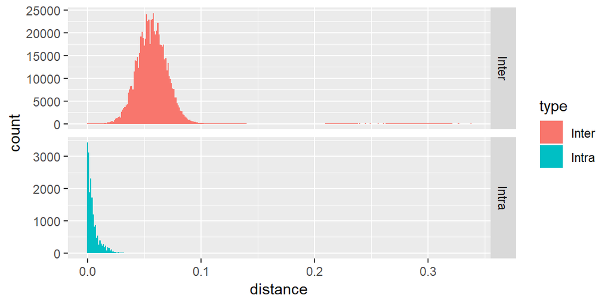

```r
pt_distance %>%
  ggplot(aes(x = distance, fill = type)) +
  geom_histogram(binwidth = 0.001) +
  facet_grid(type ~ ., scales = "free_y")
```

## Modeling

To distinguish between the two sample types (intra vs inter) is a binary classification problem.

Logistic regression is a simple algorithm for binary classification. I train a model with `distance` as independent variable, and `type` the dependent variable. I train on 100,000 observations purely to reduce computation time.

```r
pt_sample <- pt_distance %>% sample_n(1e5)
model <- glm(type ~ distance, data = pt_sample, family = binomial)
```

```
## Warning: glm.fit: fitted probabilities numerically 0 or 1 occurred
```

Note that sometimes the model throws a warning indicating numerical problems. This happens because the overlap between intra and inter is very small. If there is a very sharp dividing line between classes, the logistic regression algorithm has problems to converge.

However, in this case the numerical problems doesn’t actually cause a practical problem with model itself.

I show the model summary, in case somebody is interested. The critical point to observe is that the `distance` variable is highly significant (indicated by the ***).

```r
summary(model)
```

```
##
## Call:
## glm(formula = type ~ distance, family = binomial, data = pt_sample)
##
## Deviance Residuals:
##     Min       1Q   Median       3Q      Max
## -3.3908  -0.0067  -0.0015  -0.0003   8.4904
##
## Coefficients:
##              Estimate Std. Error z value Pr(>|z|)
## (Intercept)    5.7456     0.1744   32.95   <2e-16 ***
## distance    -341.7720     8.4741  -40.33   <2e-16 ***
## ---
## Signif. codes:  0 '***' 0.001 '**' 0.01 '*' 0.05 '.' 0.1 ' ' 1
##
## (Dispersion parameter for binomial family taken to be 1)
##
##     Null deviance: 24196.9  on 99999  degrees of freedom
## Residual deviance:  1618.7  on 99998  degrees of freedom
## AIC: 1622.7
##
## Number of Fisher Scoring iterations: 12
```

```r
newdata <-  data.frame(distance = seq(0, 0.05, by = 0.001))
pred <- predict(model, newdata, type = "response")
```

[figure not shown]

```r
plot_sample <-
  pt_sample %>%
  filter(distance <= 0.05)

plot_inter <-
  pt_sample %>%
  filter(distance <= 0.05, type == "Inter")

plot_intra <-
  pt_sample %>%
  filter(distance <= 0.05, type == "Intra")

ggplot() +
  geom_point(data = plot_inter, aes(x = distance, y = 0), alpha = 0.01, col = "blue") +
  geom_point(data = plot_intra, aes(x = distance, y = 1), alpha = 0.01, col = "red") +
  geom_line(data = newdata, aes(x = distance, y = pred)) +
  geom_text(x = 0.04, y = 0.1, label = "Type = inter") +
  geom_text(x = 0.04, y = 0.9, label = "Type = intra") +
  ggtitle("Model results", subtitle = "Predicted probability that class == 'Intra'")
```

Logistic regression essentially fits an s-curve that indicates the probability. In this case, for small distances (lower than ~0.01) the probability of being the same person (i.e. type is intra) is almost 100%. For distances greater than 0.03 the probability of being type intra is almost zero (i.e. the model predicts type inter).

## Conclusion

More work to be done here…